First, let us load the data and necessary packages:

```r
load("ames_train.Rdata")
library(MASS)
library(dplyr)
```

```r
library(ggplot2)
library(caret)
library(tidyverse)
```

# 1

Make a labeled histogram (with 30 bins) of the ages of the houses in the data set, and describe the distribution.

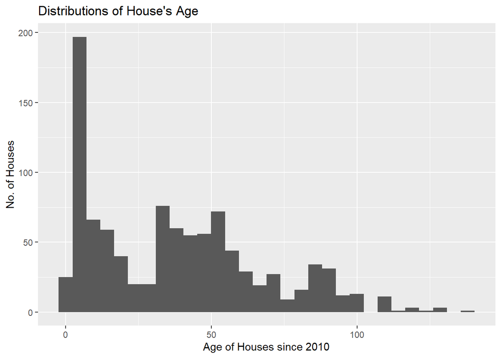

```r
# type your code for Question 1 here, and Knit
ames_train %>%
  mutate(age=max(Year.Built)- Year.Built)%>%
  ggplot(aes(x=age))+
  geom_histogram(bins = 30)+
  labs(title = "Distributions of House's Age",y="No. of Houses", x="Age of Houses since 2010")
```

The distribution is multi-modal because histogram shows couple of high counts at certain ages. Histogram is righ-skewed. No. of houses decrease with the increase in the age of th e house.

# 2

The mantra in real estate is “Location, Location, Location!” Make a graphical display that relates a home price to its neighborhood in Ames, Iowa. Which summary statistics are most appropriate to use for determining the most expensive, least expensive, and most heterogeneous (having the most variation in housing price) neighborhoods? Report which neighborhoods these are based on the summary statistics of your choice. Report the value of your chosen summary statistics for these neighborhoods.

```r
# type your code for Question 2 here, and Knit
ames_train_loc <- ames_train%>%
  select(price, Neighborhood)%>%
  group_by(Neighborhood)%>%
  summarise(median=median(price), max=max(price), min=min(price), sd=sd(price))
print(arrange(ames_train_loc, desc(max)))
```

```
## # A tibble: 27 x 5
##    Neighborhood  median    max    min      sd
##    <fct>          <dbl>  <int>  <int>   <dbl>
##  1 NridgHt      336860  615000 173000 105089.
##  2 StoneBr      340692. 591587 180000 123459.
##  3 CollgCr      195800  475000 110000  52786.
##  4 Somerst      221650  468000 139000  65199.
##  5 Timber       232500  425000 175000  84030.
##  6 Edwards      127250  415000  61500  54852.
##  7 NoRidge      290000  405000 235000  35889.
##  8 Crawfor      205000  392500  96500  71268.
##  9 Veenker      205750  385000 150000  72545.
## 10 Gilbert      183500  377500 133000  41190.
## # ... with 17 more rows
```

```r
print(arrange(ames_train_loc, min))
```

```
## # A tibble: 27 x 5
##    Neighborhood median    max   min     sd
##    <fct>         <dbl>  <int> <int>  <dbl>
##  1 OldTown      120000 265979 12789 36430.
##  2 IDOTRR        99500 150909 34900 31530.
##  3 BrkSide      124000 207000 39300 37310.
##  4 Edwards      127250 415000 61500 54852.
##  5 Sawyer       136000 219000 63900 21216.
##  6 SawyerW      182500 320000 67500 48354.
##  7 MeadowV       85750 129500 73000 18940.
##  8 NAmes        139900 277500 76500 27268.
##  9 SWISU        134000 169000 80000 27376.
## 10 NWAmes       185000 278000 82500 41341.
## # ... with 17 more rows
```

```r
print(arrange(ames_train_loc, desc(median)))
```

```
## # A tibble: 27 x 5
##    Neighborhood  median    max    min      sd
##    <fct>          <dbl>  <int>  <int>   <dbl>
##  1 StoneBr      340692. 591587 180000 123459.
##  2 NridgHt      336860  615000 173000 105089.
##  3 NoRidge      290000  405000 235000  35889.
##  4 GrnHill      280000  330000 230000  70711.
##  5 Timber       232500  425000 175000  84030.
##  6 Somerst      221650  468000 139000  65199.
##  7 Greens       212625  214000 155000  29063.
##  8 Veenker      205750  385000 150000  72545.
##  9 Crawfor      205000  392500  96500  71268.
## 10 CollgCr      195800  475000 110000  52786.
## # ... with 17 more rows
```

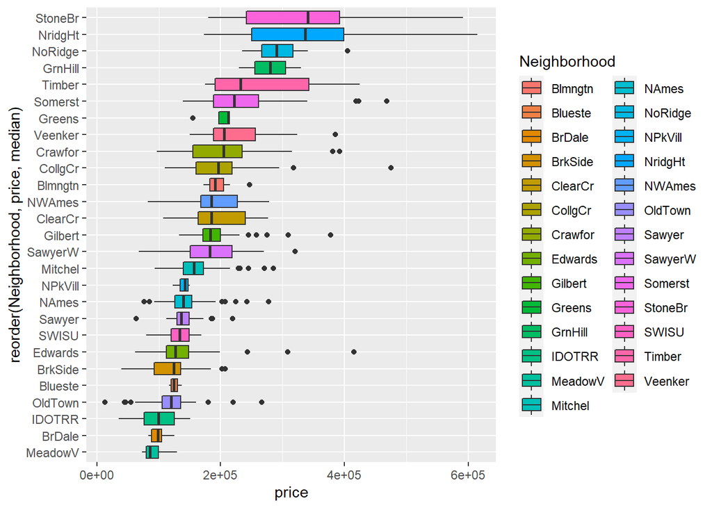

```r
ggplot(ames_train, aes(y=price, x=reorder(Neighborhood, price, median),fill=Neighborhood),main="Price of Neighborhood", xlim="Neighborhood", ylim="price")+geom_boxplot()+coord_flip()
```

Stone Brook is the most espensive neighborhood with a home price of $340691.50. The reason for this is to determine the prices range of neighborhood house price we look on the centre of measure to compare the typical house price in each neighborhood. Mean and Median are the two most common measure of centre. But here in the data we have skewed data so mean is biased as bacause data is not distributed normally. So the median is a better measure of centre as it is not sensitive to skew. For the measure of variability we look on inter quartile because standard deviation is sensitive to skewness. Meadow Village has least expensive price in neighborhood.

# 3

Which variable has the largest number of missing values? Explain why it makes sense that there are so many missing values for this variable.

```r
# type your code for Question 3 here, and Knit
ames_train_null <- summary(is.na(ames_train))[TRUE]
summary(ames_train$Pool.QC)
```

```
##   Ex   Fa   Gd   TA NA's
##    1    1    1    0  997
```

Variable with the most no. of missing values is Pool Quality.

# 4

We want to predict the natural log of the home prices. Candidate explanatory variables are lot size in square feet (Lot.Area), slope of property (Land.Slope), original construction date (Year.Built), remodel date (Year.Remod.Add), and the number of bedrooms above grade (Bedroom.AbvGr). Pick a model selection or model averaging method covered in the Specialization, and describe how this method works. Then, use this method to find the best multiple regression model for predicting the natural log of the home prices.

```r
# type your code for Question 4 here, and Knit
model_fit_1=train(log(price)~ .,
data=select(ames_train,price,Lot.Area,Land.Slope,Year.Built,Year.Remod.Add,Bedroom.AbvGr),
method="leapForward",
tuneLength=6,
tuneGrid=data.frame(nvmax=c(1:6)),
trConotrol=trainControl(method="repeatedcv", number=10, repeats=10, verboseIter=FALSE),
.method="adjr2",
trace=TRUE,
metric="RMSE")
```

```r
model_fit_1
```

```
## Linear Regression with Forward Selection
##
## 1000 samples
##    5 predictor
##
## No pre-processing
## Resampling: Bootstrapped (25 reps)
## Summary of sample sizes: 1000, 1000, 1000, 1000, 1000, 1000, ...
## Resampling results across tuning parameters:
##
##   nvmax  RMSE       Rsquared   MAE
##   1      0.3284659  0.3871746  0.2454473
##   2      0.3123724  0.4553416  0.2337592
##   3      0.2982949  0.5021107  0.2207148
##   4      0.2862546  0.5383372  0.2119444
##   5      0.2868729  0.5361712  0.2121800
##   6      0.2853045  0.5405884  0.2114683
##
## RMSE was used to select the optimal model using the smallest value.
## The final value used for the model was nvmax = 6.
```

Adding explanatory variables one at a time and prdicting the response variable then comparing the adj R square value is forward selection method used in the modeling. Each explanatory variable is added at each time and compared the adj R square value, explanatory variable with highest adj R square value added to the model then other explanatory variables added.

# 5

Which home has the largest squared residual in the previous analysis (Question 4)? Looking at all the variables in the data set, can you explain why this home stands out from the rest (what factors contribute to the high squared residual and why are those factors relevant)?

```r
# type your code for Question 5 here, and Knit
prediction=predict(model_fit_1)
residual=(log(ames_train$price)-prediction)^2
row=which.max(residual)
paste("The predicted price for the house is",format(exp(predict(model_fit_1,ames_train[row,])),big.mark=","))
```

```
## [1] "The predicted price for the house is 103,176.2"
```

```r
select(ames_train[row,],price,Lot.Area,Land.Slope,Year.Built,Year.Remod.Add,Bedroom.AbvGr)
```

```
## # A tibble: 1 x 6
##   price Lot.Area Land.Slope Year.Built Year.Remod.Add Bedroom.AbvGr
##   <int>    <int> <fct>           <int>          <int>         <int>
## 1 12789     9656 Gtl              1923           1970             2
```

Model predict price for PID 902207130 of $103,176.20 is an outlier. Actual value for this house is of $12,789.

# 6

Use the same model selection method you chose in Question 4 to again find the best multiple regression model to predict the natural log of home prices, but this time **replacing Lot.Area with log(Lot.Area)**. Do you arrive at a model including the same set of predictors?

```r
# type your code for Question 6 here, and Knit
ames_train$`log(Lot.Area)`=log(ames_train$Lot.Area)

model_fit_2=train(log(price) ~ . -Lot.Area,
                data = select(ames_train,price,Lot.Area,Land.Slope,Year.Built,Year.Remod.Add,Bedroom.AbvGr, `log(Lot.Area)`),
                method = "leapForward",
                tuneLength = 6,
                tuneGrid = data.frame(nvmax=c(1:6)),
                trControl = trainControl(method = "repeatedcv", number = 10, repeats = 10, verboseIter = FALSE),
                .method="adjr2",
                trace = TRUE,
                metric = "RMSE"
              )
```

```r
model_fit_2
```

```
## Linear Regression with Forward Selection
##
## 1000 samples
##    6 predictor
##
## No pre-processing
## Resampling: Cross-Validated (10 fold, repeated 10 times)
## Summary of sample sizes: 899, 900, 899, 899, 901, 901, ...
## Resampling results across tuning parameters:
##
##   nvmax  RMSE       Rsquared   MAE
##   1      0.3262112  0.4032596  0.2434648
##   2      0.2896432  0.5297318  0.2170388
##   3      0.2679484  0.5974301  0.2017919
##   4      0.2644828  0.6076686  0.1993362
##   5      0.2643813  0.6081885  0.1996756
##   6      0.2645702  0.6076235  0.1999355
##
## RMSE was used to select the optimal model using the smallest value.
## The final value used for the model was nvmax = 5.
```

# 7

Do you think it is better to log transform Lot.Area, in terms of assumptions for linear regression? Make graphs of the predicted values of log home price versus the true values of log home price for the regression models selected for Lot.Area and log(Lot.Area). Referencing these two plots, provide a written support that includes a quantitative justification for your answer in the first part of question 7.

```r
# type your code for Question 7 here, and Knit
model_fit_1$finalModel$xNames
```

```
## [1] "Lot.Area"       "Land.SlopeMod"  "Land.SlopeSev"  "Year.Built"
## [5] "Year.Remod.Add" "Bedroom.AbvGr"
```

```r
model_fit_1$results[6,]
```

```
##   nvmax      RMSE  Rsquared       MAE     RMSESD RsquaredSD       MAESD
## 6     6 0.2853045 0.5405884 0.2114683 0.01561113 0.03788896 0.007577725
```

```r
model_fit_2$finalModel$xNames
```

```
## [1] "Land.SlopeMod"   "Land.SlopeSev"   "Year.Built"      "Year.Remod.Add"
## [5] "Bedroom.AbvGr"   "`log(Lot.Area)`"
```

```r
model_fit_2$results[6,]
```

```
##   nvmax      RMSE  Rsquared       MAE     RMSESD RsquaredSD      MAESD
## 6     6 0.2645702 0.6076235 0.1999355 0.03169461 0.06150658 0.01486995
```

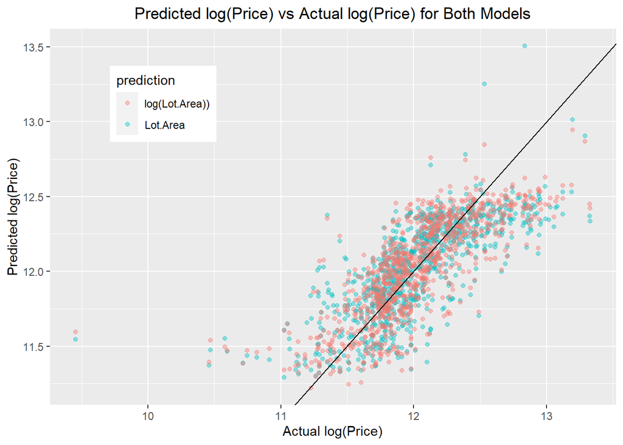

```r
true=log(ames_train$price)
prediction_1=predict(model_fit_1)
prediction_2=predict(model_fit_2)
Plot = data.frame(true=true, pred = c(prediction_1, prediction_2), prediction=c(rep(c("Lot.Area"),1000),rep(c("log(Lot.Area))"),1000)), diff=prediction_1-prediction_2)
ggplot(data=Plot, aes(x = true, y = pred, color = prediction)) +
    geom_point(,alpha = 0.4) +
    geom_abline(slope=1, intercept=0) +
    theme(legend.position=c(0.2, 0.8), plot.title = element_text(hjust = 0.5)) +
    labs(title = "Predicted log(Price) vs Actual log(Price) for Both Models", y = "Predicted log(Price)", x = "Actual log(Price)")
```

```
## Single numerical variable
## n = 2000, y-bar = 0, s = 0.0879
## H0: mu = 0
## HA: mu != 0
## t = 0, df = 1999
## p_value = 1
```

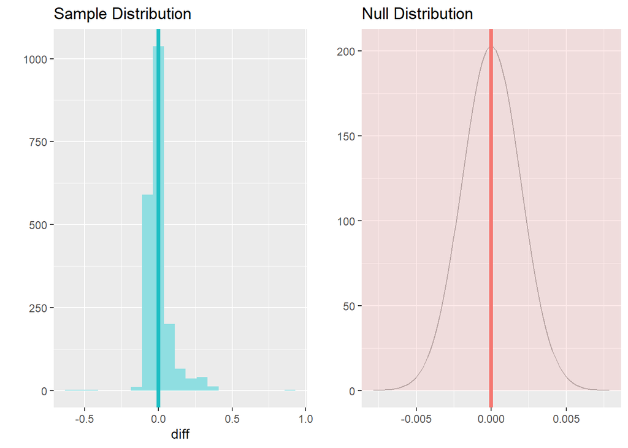

```r
statsr::inference(diff, data=Plot, type="ht", statistic = "mean", method="theoretical", alternative = "twosided", null = 0)
```

Log transformation is the best choice as it has a slightly lower prediction error and better linear fit. Model variables for model_fit_1 and model_fit_2 has right predictor.

From 1000 data points it is very difficult to say that this data has enough proof to add furhter complexity to the model by log transformation to the LOt.Area variable beacuse there is not a statistically significant difference in the distribution of results for model_fit_1 and model_fit_2.

### 7.0.1